# End of File VS Code Windows

Andrew Alverson and John Tipton

Created: 9/18/2020 Last modified: 9/18/2020

There are issues when sharing files that are created on Windows machines when using the file on a linux-based machine (including MacOS). This is related to the way a computer defines a new line (`\n` in linux and `\r\n` on Windows).

To get to the options to change the line files, open the settings by clicking the gear icon in the lower left and then choose settings.

[figure not shown]

Once the settings window opens, in the search bar at the top of the window, search for `end of line` and hit return. This will open a bunch of options. In the option `Files: Eol` there will be a drop-down menu. Choose the drop down menu and select the `\n` option. At the bottom of the drop-down menu, this will then show `LF`.

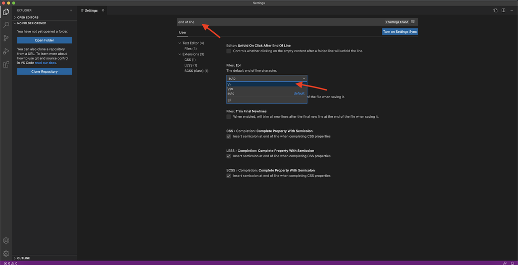

Open up a new python script and verify that the end of line file type is `LF` in the lower menu bar. If the end of line file type shows `CRLF`, quit and restart VS code. If the end of line file is still `CRLF` repeat the process listed above.

[figure not shown]

# 1 References

This tutorial was based on https://qvault.io/2020/06/18/how-to-get-consistent-line-breaks-in-vs-code-lf-vs-crlf/